# STATS 326/786

Week 4 Tutorial

# Problem 1

> Below is some fake seasonal data with a perfectly periodic pattern, no trend-cycle, and no remainder components. In class, we learned that moving averages (MA) are useful for smoothing time series and estimating a trend-cycle. A $2 \times 4~\text{MA}$ and a $5~\text{MA}$ have been overlaid on the original time series. What do you notice about the MAs, and why might this be happening?

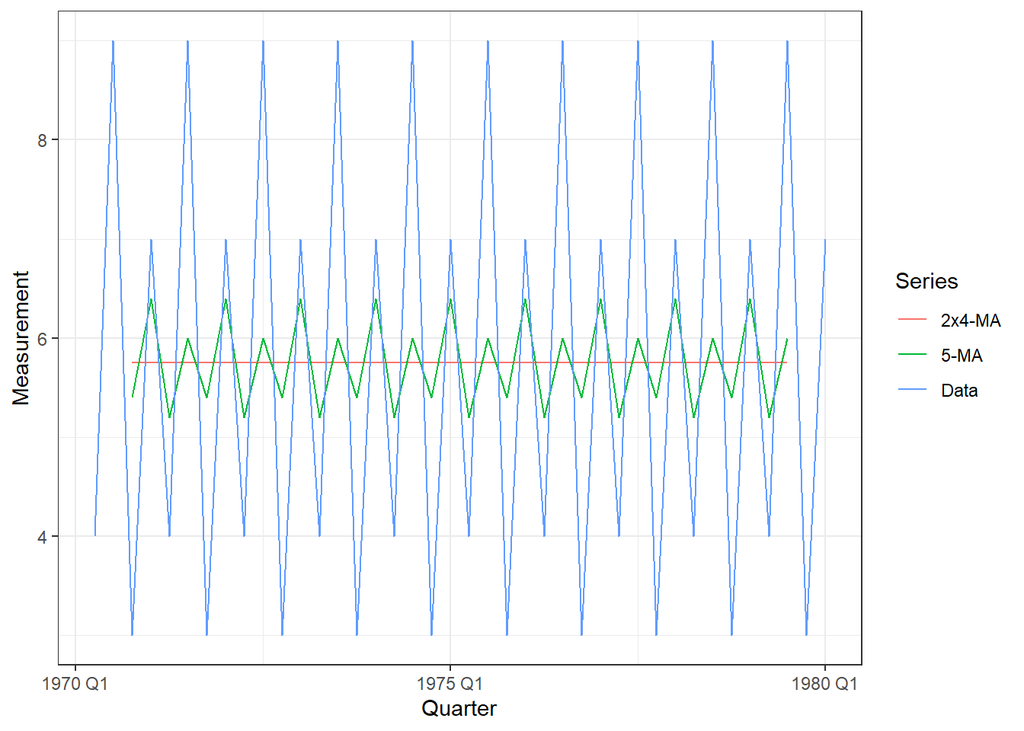

> Repeat the above exercise, but for the fake data below. This data is seasonal (again, with a perfectly periodic pattern) with a linear trend and no remainder component.

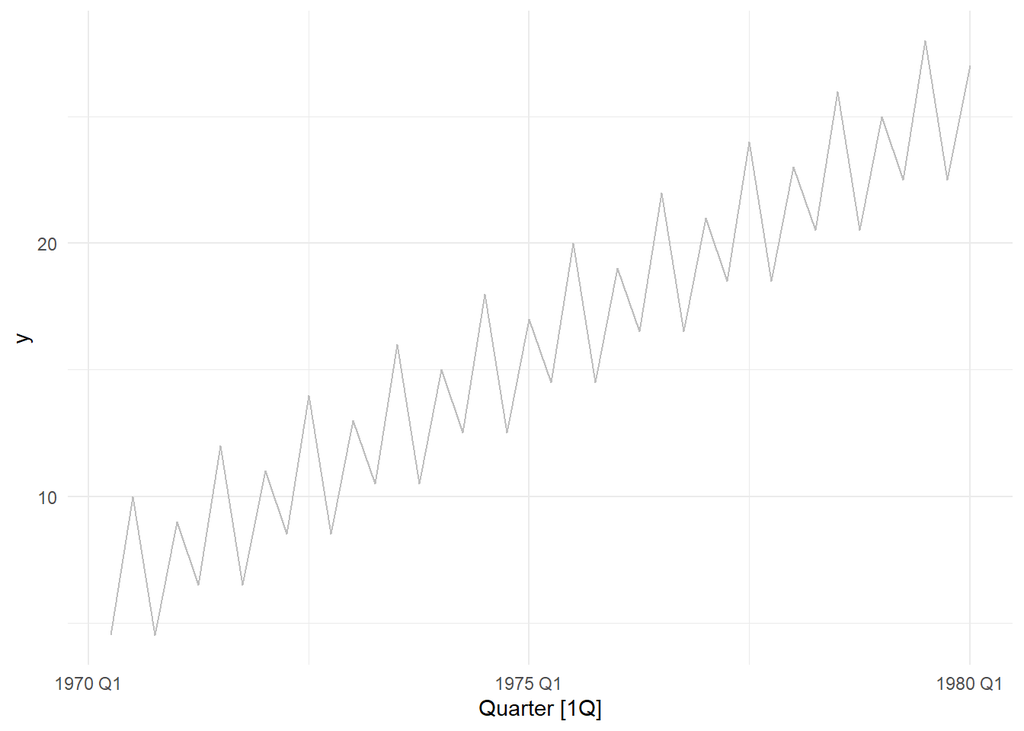

> If you were to apply a $3 \times 5~\text{MA}$ to a time series, analytically derive the weights that each observation contributes to the moving-averaged time series at time $t$.

# Problem 2

> Below is an example of a time series with multiplicative seasonality. In this problem, you learn how to perform your own (multiplicative) classical decomposition from first principles.

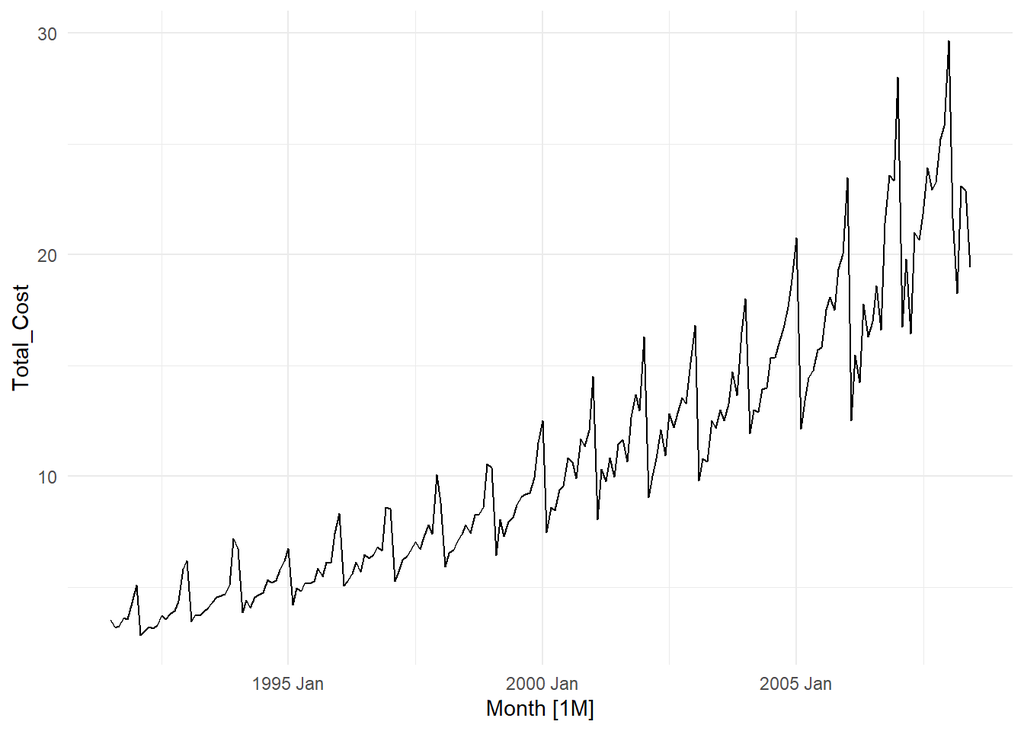

> Calculate the trend-cycle by performing a $2\times 12~\text{MA}$ on your time series.

> Compute the detrended time series (original time series divided by trend).

> Calculate the seasonal factor for each month (noting that these must sum to 12 for a monthly time series).

> Merge your data sets so the seasonal factor is now included in your original tsibble.

> Compute the remainder component (as detrended divided by seasonal) and seasonally-adjusted component (as original time series divided by seasonal).

> Plot the original time series and overlay it with the trend-cycle and seasonally-adjusted series.

> Extra: See if you can re-create the classical decomposition plot.